# SPS_DATA607_Week3B_DC

# Window Functions

Data set from https://www.bitget.com/price/filecoin/historical-data

## Running Code

```r
library(dplyr)
library(ggplot2)
library(tidyverse)
mydata <- read.csv("https://raw.githubusercontent.com/dyc-sps/SPS_DATA607_Week3B/refs/heads/main/filecoin.csv")
summary(mydata)
```

```
    timeOpen           timeClose            timeHigh
 Min.   :1.535e+12   Min.   :1.535e+12   Min.   :1.535e+12
 1st Qu.:1.594e+12   1st Qu.:1.594e+12   1st Qu.:1.594e+12
 Median :1.652e+12   Median :1.652e+12   Median :1.652e+12
 Mean   :1.653e+12   Mean   :1.653e+12   Mean   :1.653e+12
 3rd Qu.:1.712e+12   3rd Qu.:1.712e+12   3rd Qu.:1.712e+12
 Max.   :1.771e+12   Max.   :1.771e+12   Max.   :1.771e+12
    timeLow            priceOpen          priceHigh           priceLow
 Min.   :1.535e+12   Min.   :  0.8819   Min.   :  0.9422   Min.   :  0.6336
 1st Qu.:1.594e+12   1st Qu.:  3.5518   1st Qu.:  3.7537   1st Qu.:  3.3225
 Median :1.652e+12   Median :  5.0781   Median :  5.3625   Median :  4.7555
 Mean   :1.653e+12   Mean   : 15.3725   Mean   : 16.1979   Mean   : 14.5478
 3rd Qu.:1.712e+12   3rd Qu.: 13.0953   3rd Qu.: 14.4798   3rd Qu.: 11.8922
 Max.   :1.771e+12   Max.   :191.1539   Max.   :237.2418   Max.   :182.7141
   priceClose           volume
 Min.   :  0.8819   Min.   :5.112e+04
 1st Qu.:  3.5471   1st Qu.:1.433e+07
 Median :  5.0790   Median :1.361e+08
 Mean   : 15.3672   Mean   :2.967e+08
 3rd Qu.: 13.0927   3rd Qu.:2.995e+08
 Max.   :191.3565   Max.   :1.237e+10
```

```r
head(mydata)
```

```
     timeOpen   timeClose    timeHigh     timeLow priceOpen priceHigh  priceLow
1 1.77072e+12 1.77081e+12 1.77073e+12 1.77079e+12 0.9371375 0.9422195 0.8818362
2 1.77064e+12 1.77072e+12 1.77065e+12 1.77068e+12 0.9327586 0.9459684 0.8937898
3 1.77055e+12 1.77064e+12 1.77056e+12 1.77061e+12 0.9756082 0.9799408 0.9228659
4 1.77047e+12 1.77055e+12 1.77053e+12 1.77049e+12 0.9765257 0.9957679 0.9464217
5 1.77038e+12 1.77047e+12 1.77044e+12 1.77038e+12 0.8819155 0.9852578 0.7998295
6 1.77029e+12 1.77038e+12 1.77030e+12 1.77037e+12 1.0483603 1.0572914 0.8800285
  priceClose    volume
1  0.9004138  81084504
2  0.9371375  92338061
3  0.9327679  81278743
4  0.9756082 137038993
5  0.9765257 254306881
6  0.8818979 247946373
```

```r
glimpse(mydata)
```

```
Rows: 2,713
Columns: 9
$ timeOpen   <dbl> 1.77072e+12, 1.77064e+12, 1.77055e+12, 1.77047e+12, 1.77038…
$ timeClose  <dbl> 1.77081e+12, 1.77072e+12, 1.77064e+12, 1.77055e+12, 1.77047…
$ timeHigh   <dbl> 1.77073e+12, 1.77065e+12, 1.77056e+12, 1.77053e+12, 1.77044…
$ timeLow    <dbl> 1.77079e+12, 1.77068e+12, 1.77061e+12, 1.77049e+12, 1.77038…
$ priceOpen  <dbl> 0.9371375, 0.9327586, 0.9756082, 0.9765257, 0.8819155, 1.04…
$ priceHigh  <dbl> 0.9422195, 0.9459684, 0.9799408, 0.9957679, 0.9852578, 1.05…
$ priceLow   <dbl> 0.8818362, 0.8937898, 0.9228659, 0.9464217, 0.7998295, 0.88…
$ priceClose <dbl> 0.9004138, 0.9371375, 0.9327679, 0.9756082, 0.9765257, 0.88…
$ volume     <dbl> 81084504, 92338061, 81278743, 137038993, 254306881, 2479463…
```

Convert the timestamp column to UTC timezone format.

```r
mydata <- mydata %>%
  mutate(timeCl = as.Date(as.POSIXct(mydata$timeClose / 1000, origin = "1970-01-01", tz = "UTC"))) %>%
  mutate(timeOp = as.Date(as.POSIXct(mydata$timeOpen / 1000, origin = "1970-01-01", tz = "UTC"))) %>%
  mutate(timeHi = as.Date(as.POSIXct(mydata$timeHigh / 1000, origin = "1970-01-01", tz = "UTC"))) %>%
  mutate(timeLo = as.Date(as.POSIXct(mydata$timeLow / 1000, origin = "1970-01-01", tz = "UTC")))
colnames(mydata)
```

```
 [1] "timeOpen"   "timeClose"  "timeHigh"   "timeLow"    "priceOpen"
 [6] "priceHigh"  "priceLow"   "priceClose" "volume"     "timeCl"
[11] "timeOp"     "timeHi"     "timeLo"
```

```r
mydata_utc <- mydata %>%
  select(timeopen=timeOp,priceOpen,priceClose,priceHigh,priceLow,volume) %>%
  # select(timeopen=timeOp,timeclose=timeCl,timehigh=timeHi,timelow=timeLo,priceOpen,priceClose,priceHigh,priceLow,volume) %>%
  mutate(volume_million = round(volume / 1e6, 2))
summary(mydata_utc)
```

```
    timeopen            priceOpen          priceClose         priceHigh
 Min.   :2018-08-22   Min.   :  0.8819   Min.   :  0.8819   Min.   :  0.9422
 1st Qu.:2020-06-30   1st Qu.:  3.5518   1st Qu.:  3.5471   1st Qu.:  3.7537
 Median :2022-05-09   Median :  5.0781   Median :  5.0790   Median :  5.3625
 Mean   :2022-05-14   Mean   : 15.3725   Mean   : 15.3672   Mean   : 16.1979
 3rd Qu.:2024-04-03   3rd Qu.: 13.0953   3rd Qu.: 13.0927   3rd Qu.: 14.4798
 Max.   :2026-02-10   Max.   :191.1539   Max.   :191.3565   Max.   :237.2418
    priceLow            volume          volume_million
 Min.   :  0.6336   Min.   :5.112e+04   Min.   :    0.05
 1st Qu.:  3.3225   1st Qu.:1.433e+07   1st Qu.:   14.33
 Median :  4.7555   Median :1.361e+08   Median :  136.07
 Mean   : 14.5478   Mean   :2.967e+08   Mean   :  296.68
 3rd Qu.: 11.8922   3rd Qu.:2.995e+08   3rd Qu.:  299.47
 Max.   :182.7141   Max.   :1.237e+10   Max.   :12367.98
```

Create year and month fields to support grouping and aggregation.

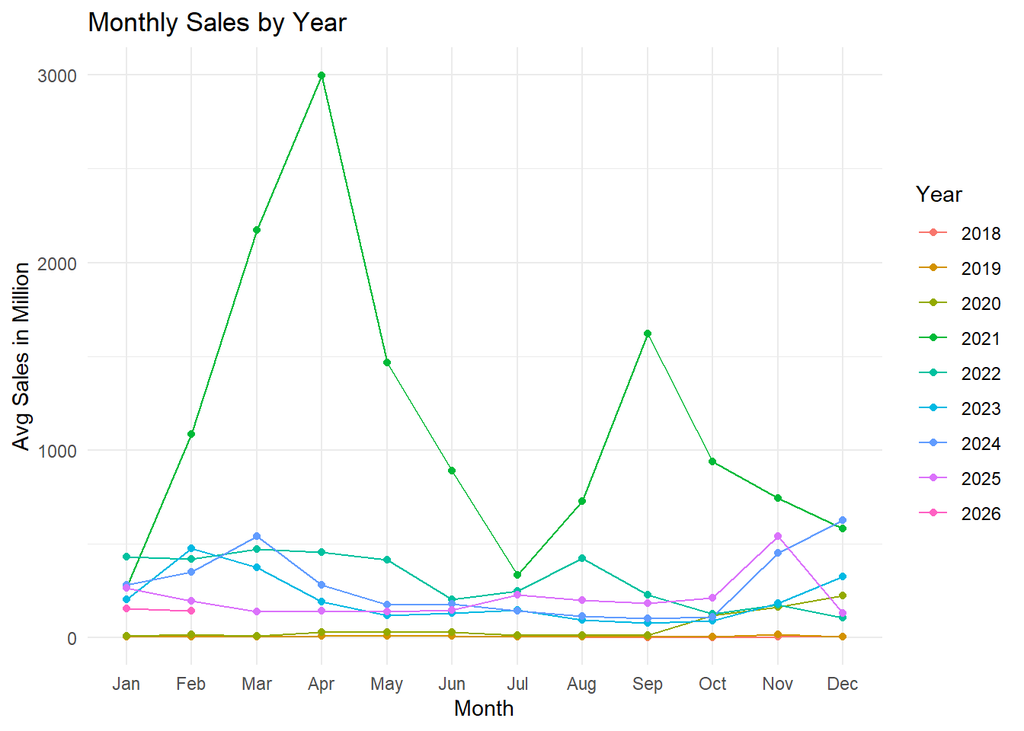

```r
mydata_utc_monthly <- mydata_utc %>%
  mutate(year = year(timeopen),month = month(timeopen,label = TRUE, abbr = TRUE)) %>%
  group_by(year, month)%>%
  summarise(avg_sales = mean(volume_million, na.rm = TRUE), .groups = "drop")

labels <- mydata_utc_monthly %>%
  group_by(year) %>%
  filter(month == max(month)) %>%
  ungroup()

ggplot(mydata_utc_monthly, aes(x = month, y = avg_sales, group = year, color = factor(year))) +
  geom_line() +
  geom_point() +
  #geom_text(data = labels,aes(label = year), hjust = -0.2, vjust = 0.5, size = 4) +
  labs(title = "Monthly Sales by Year",
       x = "Month",
       y = "Avg Sales in Million",
       color = "Year") +
  scale_x_discrete(drop = FALSE) +
  theme_minimal()
```

```r
ggplot(mydata_utc_monthly, aes(x = month, y = avg_sales, group = year, color = factor(year))) +
  geom_line() +
  geom_point() +
  #geom_text(data = labels,aes(label = year), hjust = -0.2, vjust = 0.5, size = 4) +
  labs(title = "Monthly Sales by Year",
       x = "Month",
       y = "Avg Sales in Million",
       color = "Year") +
  scale_x_discrete(drop = FALSE) +

  theme_minimal()+

  #facet_wrap(~year)
  #facet_wrap(~year, ncol = 1, scales = "free_y")
  #facet_wrap(~year, ncol = 1)
facet_grid(year ~.)+
theme(panel.spacing = unit(1.5, "lines"),
        strip.text.y = element_text(size = 12))
```

```r
ggsave("monthly_sales.png", width = 8, height = 12)
```

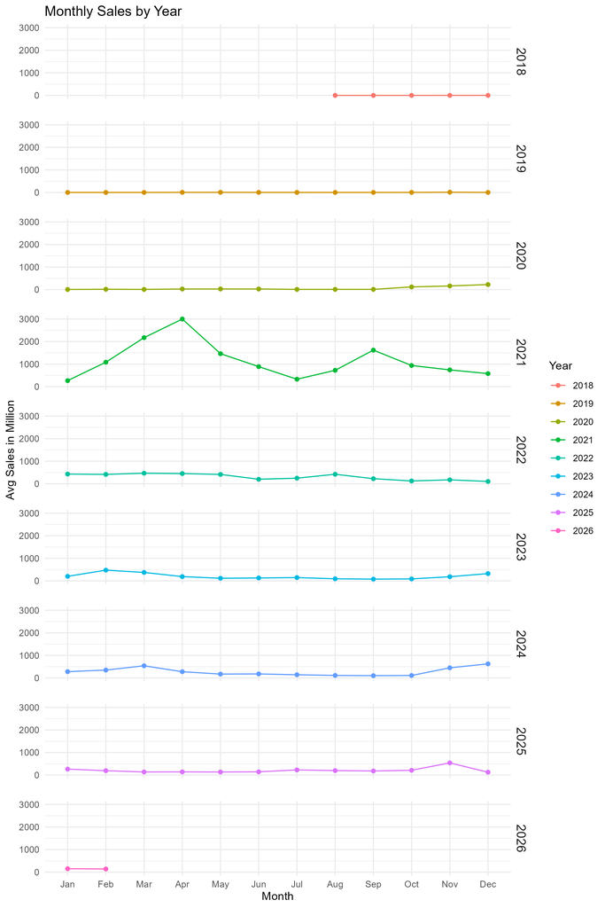

### 6-days moving average

```r
#install.packages("slider")
library(slider)
mydata_utc <- mydata_utc %>%
  arrange(timeopen)%>%
  mutate(ma_6day = slide_dbl(volume_million, mean, .before = 5, .complete = TRUE))

ggplot(mydata_utc, aes(x = timeopen)) +
  geom_line(aes(y = volume_million, color = "Volume"), linewidth = 1) +
  geom_line(aes(y = ma_6day, color = "6-Day MA"), linewidth = 1) +
  scale_color_manual(values = c("Volume" = "steelblue", "6-Day MA" = "red")) +
  labs(x = " Year ", y = "Volume in million", color = "Legend") +
  theme_minimal()
ggsave("m6_days_sales.png", width = 8, height = 6)
```

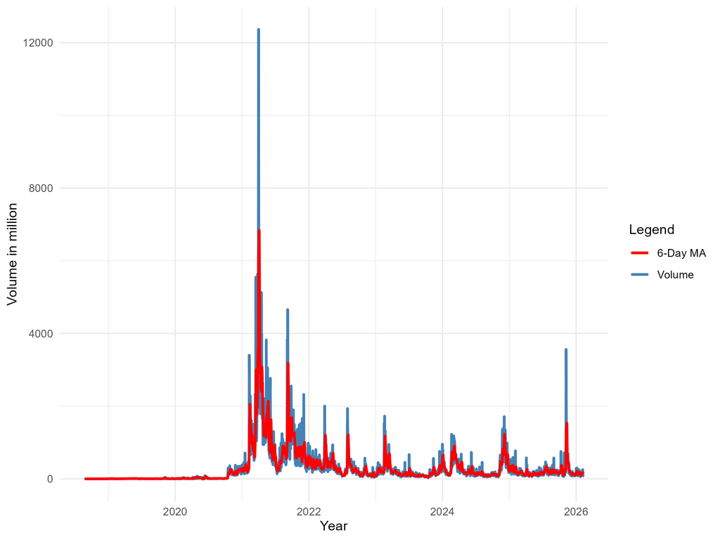

## Conclusion

The 6-day moving average, calculated using window functions, provides a smoothed view of the volume over time, reducing the impact of daily fluctuations or anomalies. By applying the window function (slide_dbl), each data point incorporates the values of the previous 5 days plus the current day, giving a rolling average that highlights underlying trends.

From the analysis:

1. Short-term spikes or drops in volume are effectively smoothed, making trends more visible.compare the blue line and red line in the last figure
2. Comparing the raw volume to the 6-day moving average allows us to quickly identify periods of sustained increase or decrease.
3. Window functions make it easy to compute such rolling aggregates without collapsing the dataset, preserving the granularity of daily data for further analysis.

Overall, the 6-day moving average serves as a robust indicator of short-term trends, while window functions provide the flexibility to calculate it efficiently and consistently across the dataset.

### LLMS used:

• OpenAI. (2025). ChatGPT (Version 5.2) [Large language model]. https://chat.openai.com. Accessed Feb 14, 2026.